# Compare RAVG vs. GEE Fire Severity Estimates

Ali Paulson

2/8/2022

We were not able to get fire severity estimates from RAVG for all of the 2020 fires that were part of the Global Ecology and Biogeography manuscript. Ali used Google Earth Engine (based on Sean Parks’s code) to develop initial fire severity estimates for each missing fire.

*Question*: How well do the initial fire severity estimates from Google Earth Engine align with initial severity estimates from RAVG? [Zack Steel already did a similar assessment of extended fire severity estimates from GEE vs. Miller’s severity products, and found a very close correspondence]

*Methods*: RAVG data were available for 18 of the 40 fires we considered for the GEB manuscript. I ran these same 18 fires using an adjusted version of Sean Parks’s code to obtain initial estimates of RdNBR fire severity.

- I used a date range of 10/1/2020 through 12/7/2020 for imagery for each of the 18 fires. For the fires used in the manuscript (and those provided to UFSS R5 Ecology program for the POSCRPT analysis), I investigated each individual fire to determine an appropriate date range for imagery. This was especially important for very late-season fires, where only November/December imagery should have been used. Thus, the date range used here may not be perfect.
- I then calculated the percent of each fire that was classified (based on Lydersen et al. 2018) as high severity using RAVG vs. GEE.
- I also used bilinear interpolation to extract the RdNBR severity estimate for each point on a 90m grid across each fire. I followed Lydersen et al. 2018 to classify each estimate as unchanged, low, moderate, or high severity. I then used a confusion matrix to assess the correspondence between each method for a) all severity classes and b) high severity classification.

*Results*: There is a strong correlation between the percent area estimated to have burned at high severity across these 18 fires for the GEE and RAVG methods (r=0.94). When assessing the classification on a point-by-point basis, the two methods correspond well for the high severity classification, but do not correspond as well when comparing the unchanged, low, moderate, and high severity classes. Nevertheless, there is still 78% accuracy across the four classes, which is pretty good, and is in line or better than other estimates like this.

## Compare Percent of Area Burned at High Severity:

I first calculated the area classified as “high severity” for each of the 18 fires that were run with both RAVG and Google Earth Engine. RAVG and GEE estimates are strongly correlated (Pearson’s Correlation = 0.939, p-value = 8.07^{-9}).

The Caldwell Fire appears to be an outlier. It has a RAVG percent high severity estimate of 59% and a GEE percent high severity estimate of 82%. This was an early season fire (July 22, 2020 through September 1, 2020), so it is likely that the date range I used in GEE was not appropriate.

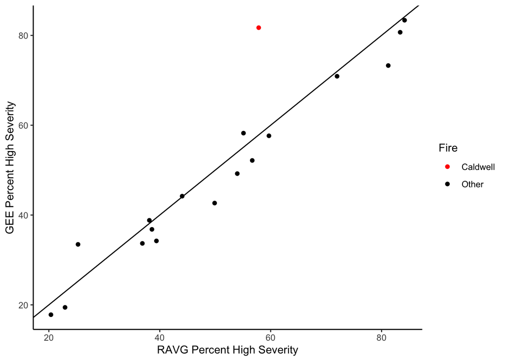

## Compare RdNBR estimates on 90-m grid:

Next, let’s compare severity classifications using a 90m grid across each fire. For this analysis, I used bilinear interpolation to extract the RdNBR value at each point on a 90-m grid across each fire. I then classified these RdNBR values as unchanged, low, moderate, or high, based on Lydersen et al. 2018 for initial severity estimates.

```
## Confusion Matrix and Statistics
##
##            Reference
## Prediction  unchanged    low moderate   high
##   unchanged    104611  24514     2015   1175
##   low           88117 231687    22118   5340
##   moderate       4108  59795   195235  39919
##   high           1065   4026    52828 536743
##
## Overall Statistics
##
##                Accuracy : 0.7779
##                  95% CI : (0.7772, 0.7786)
##     No Information Rate : 0.4247
##     P-Value [Acc > NIR] : < 2.2e-16
##
##                   Kappa : 0.6828
##
##  Mcnemar's Test P-Value : < 2.2e-16
##
## Statistics by Class:
##
##                      Class: unchanged Class: low Class: moderate Class: high
## Sensitivity                   0.52860     0.7240          0.7173      0.9204
## Specificity                   0.97643     0.8903          0.9057      0.9267
## Pos Pred Value                0.79062     0.6672          0.6528      0.9026
## Neg Pred Value                0.92483     0.9139          0.9284      0.9404
## Prevalence                    0.14411     0.2330          0.1982      0.4247
## Detection Rate                0.07618     0.1687          0.1422      0.3908
## Detection Prevalence          0.09635     0.2529          0.2178      0.4330
## Balanced Accuracy             0.75252     0.8071          0.8115      0.9235
```

next, let’s look at the confusion matrix for high severity vs. all other classifications. In the table below, 0 represents unchanged, low, or moderate classification; 1 represents high severity classification. Overall, there is 92.4% accuracy (correspondence) between the two methods. Sensitivity (which measures how often the two methods agree that a point had the same severity classification) is 92.6%, and specificity (which measures how often the two methods agree that points do not belong to a given severity classification) was 92%.

```
## Confusion Matrix and Statistics
##
##           Reference
## Prediction      0      1
##          0 732200  46434
##          1  57919 536743
##
##                Accuracy : 0.924
##                  95% CI : (0.9236, 0.9245)
##     No Information Rate : 0.5753
##     P-Value [Acc > NIR] : < 2.2e-16
##
##                   Kappa : 0.8449
##
##  Mcnemar's Test P-Value : < 2.2e-16
##
##             Sensitivity : 0.9267
##             Specificity : 0.9204
##          Pos Pred Value : 0.9404
##          Neg Pred Value : 0.9026
##              Prevalence : 0.5753
##          Detection Rate : 0.5332
##    Detection Prevalence : 0.5670
##       Balanced Accuracy : 0.9235
##
##        'Positive' Class : 0
##
```